# Construct Two Parameter Hierarchical P/NBD Model for Short Timeframe Synthetic Data

Author

Mick Cooney mickcooney@gmail.com

Published

February 16, 2024

## 0.1 Load Short-Timeframe Synthetic Transaction Data

```r
customer_cohortdata_tbl <- read_rds("data/shortsynth_customer_cohort_data_tbl.rds")
customer_cohortdata_tbl |> glimpse()
```

```
Rows: 5,000
Columns: 5
$ customer_id     <chr> "SFC202001_0001", "SFC202001_0002", "SFC202001_0003", …
$ cohort_qtr      <chr> "2020 Q1", "2020 Q1", "2020 Q1", "2020 Q1", "2020 Q1",…
$ cohort_ym       <chr> "2020 01", "2020 01", "2020 01", "2020 01", "2020 01",…
$ first_tnx_date  <dttm> 2020-01-01 15:26:03, 2020-01-01 08:00:48, 2020-01-01 …
$ total_tnx_count <int> 4, 5, 1, 1, 6, 1, 5, 5, 1, 2, 3, 11, 1, 5, 1, 1, 16, 1…
```

```r
customer_transactions_tbl <- read_rds("data/shortsynth_transaction_data_tbl.rds")
customer_transactions_tbl |> glimpse()
```

```
Rows: 29,504
Columns: 8
$ customer_id   <fct> SFC202001_0002, SFC202001_0004, SFC202001_0001, SFC20200…
$ tnx_timestamp <dttm> 2020-01-01 08:00:48, 2020-01-01 14:02:22, 2020-01-01 15…
$ tnx_dow       <fct> Wed, Wed, Wed, Wed, Thu, Thu, Thu, Thu, Thu, Thu, Fri, F…
$ tnx_month     <fct> Jan, Jan, Jan, Jan, Jan, Jan, Jan, Jan, Jan, Jan, Jan, J…
$ tnx_week      <chr> "00", "00", "00", "00", "00", "00", "00", "00", "00", "0…
$ invoice_id    <chr> "T20200101-0001", "T20200101-0002", "T20200101-0003", "T…
$ tnx_amount    <dbl> 120.46, 208.45, 386.80, 111.52, 133.66, 133.52, 26.19, 1…
$ orig_id       <chr> "SFC202001_0002", "SFC202001_0004", "SFC202001_0001", "S…
```

```r
customer_subset_id <- read_rds("data/shortsynth_customer_subset_ids.rds")
customer_subset_id |> glimpse()
```

```
 Factor w/ 5000 levels "SFC202001_0002",..: 2 3 8 10 14 16 17 21 25 27 ...
```

We re-produce the visualisation of the transaction times we used in previous workbooks.

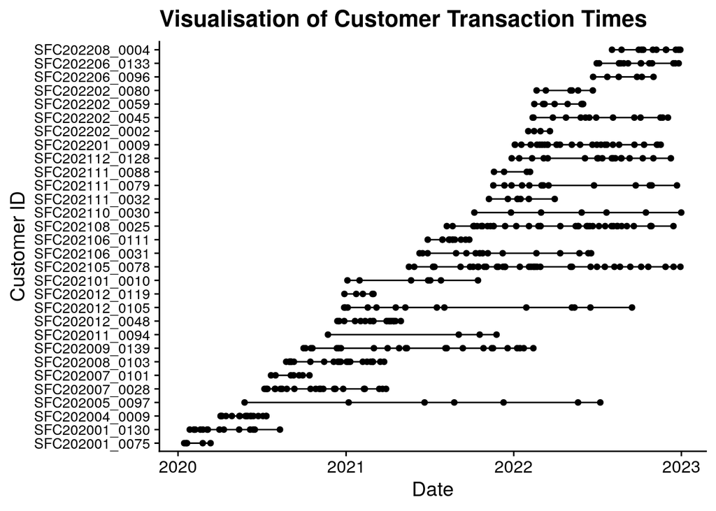

```r
plot_tbl <- customer_transactions_tbl |>
  group_nest(customer_id, .key = "cust_data") |>
  filter(map_int(cust_data, nrow) > 3) |>
  slice_sample(n = 30) |>
  unnest(cust_data)

ggplot(plot_tbl, aes(x = tnx_timestamp, y = customer_id)) +
  geom_line() +
  geom_point() +
  labs(
      x = "Date",
      y = "Customer ID",
      title = "Visualisation of Customer Transaction Times"
    ) +
  theme(axis.text.y = element_text(size = 10))
```

## 0.2 Load Derived Data

```r
obs_fitdata_tbl   <- read_rds("data/shortsynth_obs_fitdata_tbl.rds")
obs_validdata_tbl <- read_rds("data/shortsynth_obs_validdata_tbl.rds")

customer_fit_stats_tbl <- obs_fitdata_tbl |>
  rename(x = tnx_count)
```

## 0.3 Load Subset Data

We also want to construct our data subsets for the purposes of speeding up our valuations.

```r
customer_fit_subset_tbl <- obs_fitdata_tbl |>
  filter(customer_id %in% customer_subset_id)

customer_fit_subset_tbl |> glimpse()
```

```
Rows: 1,000
Columns: 6
$ customer_id    <fct> SFC202001_0004, SFC202001_0001, SFC202001_0008, SFC2020…
$ first_tnx_date <dttm> 2020-01-01 14:02:22, 2020-01-01 15:26:03, 2020-01-02 1…
$ last_tnx_date  <dttm> 2020-01-01 14:02:22, 2020-02-27 10:26:24, 2020-06-14 2…
$ tnx_count      <dbl> 0, 3, 4, 0, 10, 0, 2, 0, 1, 4, 1, 16, 3, 2, 7, 0, 1, 5,…
$ t_x            <dbl> 0.0000000, 8.1131300, 23.4784803, 0.0000000, 28.6442666…
$ T_cal          <dbl> 104.3450, 104.3367, 104.2137, 104.1611, 104.0805, 104.0…
```

```r
customer_valid_subset_tbl <- obs_validdata_tbl |>
  filter(customer_id %in% customer_subset_id)

customer_valid_subset_tbl |> glimpse()
```

```
Rows: 1,000
Columns: 3
$ customer_id       <fct> SFC202001_0004, SFC202001_0001, SFC202001_0008, SFC2…
$ tnx_count         <dbl> 0, 0, 0, 0, 0, 0, 0, 0, 0, 0, 0, 0, 0, 0, 0, 0, 0, 0…
$ tnx_last_interval <dbl> NA, NA, NA, NA, NA, NA, NA, NA, NA, NA, NA, NA, NA, …
```

We now use these datasets to set the start and end dates for our various validation methods.

```r
dates_lst <- read_rds("data/shortsynth_simulation_dates.rds")

use_fit_start_date <- dates_lst$use_fit_start_date
use_fit_end_date   <- dates_lst$use_fit_end_date

use_valid_start_date <- dates_lst$use_valid_start_date
use_valid_end_date   <- dates_lst$use_valid_end_date
```

We now split out the transaction data into fit and validation datasets.

```r
customer_fit_transactions_tbl <- customer_transactions_tbl |>
  filter(
    customer_id %in% customer_subset_id,
    tnx_timestamp >= use_fit_start_date,
    tnx_timestamp <= use_fit_end_date
    )

customer_fit_transactions_tbl |> glimpse()
```

```
Rows: 5,080
Columns: 8
$ customer_id   <fct> SFC202001_0004, SFC202001_0001, SFC202001_0008, SFC20200…
$ tnx_timestamp <dttm> 2020-01-01 14:02:22, 2020-01-01 15:26:03, 2020-01-02 12…
$ tnx_dow       <fct> Wed, Wed, Thu, Thu, Fri, Fri, Fri, Sat, Sat, Sun, Sun, M…
$ tnx_month     <fct> Jan, Jan, Jan, Jan, Jan, Jan, Jan, Jan, Jan, Jan, Jan, J…
$ tnx_week      <chr> "00", "00", "00", "00", "00", "00", "00", "00", "00", "0…
$ invoice_id    <chr> "T20200101-0002", "T20200101-0003", "T20200102-0004", "T…
$ tnx_amount    <dbl> 208.45, 386.80, 154.71, 80.41, 135.19, 159.46, 229.79, 9…
$ orig_id       <chr> "SFC202001_0004", "SFC202001_0001", "SFC202001_0008", "S…
```

```r
customer_valid_transactions_tbl <- customer_transactions_tbl |>
  filter(
    customer_id %in% customer_subset_id,
    tnx_timestamp >= use_valid_start_date,
    tnx_timestamp <= use_valid_end_date
    )

customer_valid_transactions_tbl |> glimpse()
```

```
Rows: 1,680
Columns: 8
$ customer_id   <fct> SFC202109_0029, SFC202112_0135, SFC202011_0128, SFC20211…
$ tnx_timestamp <dttm> 2022-01-01 01:32:25, 2022-01-01 02:51:43, 2022-01-01 03…
$ tnx_dow       <fct> Sat, Sat, Sat, Sat, Sat, Sat, Sat, Sat, Sun, Sun, Sun, S…
$ tnx_month     <fct> Jan, Jan, Jan, Jan, Jan, Jan, Jan, Jan, Jan, Jan, Jan, J…
$ tnx_week      <chr> "00", "00", "00", "00", "00", "00", "00", "00", "00", "0…
$ invoice_id    <chr> "T20220101-0004", "T20220101-0006", "T20220101-0008", "T…
$ tnx_amount    <dbl> 99.76, 219.92, 315.00, 207.41, 466.45, 168.03, 107.16, 1…
$ orig_id       <chr> "SFC202109_0029", "SFC202112_0135", "SFC202011_0128", "S…
```

Finally, we want to extract the first transaction for each customer, so we can add this data to assess our models.

```r
customer_initial_tnx_tbl <- customer_fit_transactions_tbl |>
  slice_min(n = 1, order_by = tnx_timestamp, by = customer_id)

customer_initial_tnx_tbl |> glimpse()
```

```
Rows: 1,000
Columns: 8
$ customer_id   <fct> SFC202001_0004, SFC202001_0001, SFC202001_0008, SFC20200…
$ tnx_timestamp <dttm> 2020-01-01 14:02:22, 2020-01-01 15:26:03, 2020-01-02 12…
$ tnx_dow       <fct> Wed, Wed, Thu, Thu, Fri, Fri, Fri, Sat, Sat, Sun, Sun, M…
$ tnx_month     <fct> Jan, Jan, Jan, Jan, Jan, Jan, Jan, Jan, Jan, Jan, Jan, J…
$ tnx_week      <chr> "00", "00", "00", "00", "00", "00", "00", "00", "00", "0…
$ invoice_id    <chr> "T20200101-0002", "T20200101-0003", "T20200102-0004", "T…
$ tnx_amount    <dbl> 208.45, 386.80, 154.71, 80.41, 135.19, 159.46, 229.79, 9…
$ orig_id       <chr> "SFC202001_0004", "SFC202001_0001", "SFC202001_0008", "S…
```

We now expand out these initial transactions so that we can append them to our simulations.

```r
sim_init_tbl <- customer_initial_tnx_tbl |>
  transmute(
    customer_id,
    draw_id       = list(1:n_sim),
    tnx_timestamp,
    tnx_amount
    ) |>
  unnest(draw_id)

sim_init_tbl |> glimpse()
```

```
Rows: 2,000,000
Columns: 4
$ customer_id   <fct> SFC202001_0004, SFC202001_0004, SFC202001_0004, SFC20200…
$ draw_id       <int> 1, 2, 3, 4, 5, 6, 7, 8, 9, 10, 11, 12, 13, 14, 15, 16, 1…
$ tnx_timestamp <dttm> 2020-01-01 14:02:22, 2020-01-01 14:02:22, 2020-01-01 14…
$ tnx_amount    <dbl> 208.45, 208.45, 208.45, 208.45, 208.45, 208.45, 208.45, …
```

Before we start on that, we set a few parameters for the workbook to organise our Stan code.

```r
stan_modeldir <- "stan_models"
stan_codedir  <-   "stan_code"
```

# 1 Fit Hierarchical Mean-Lambda, Mean-Mu Model

Our first model puts a hierarchical prior around the mean of both the population $\lambda$, `lambda_mn`, and population $\mu$, `mu_mn`.

Once again we use a Gamma prior for both these parameters

## 1.1 Compile and Fit Stan Model

We now compile this model using `CmdStanR`.

```r
pnbd_twohiermean_stanmodel <- cmdstan_model(
  "stan_code/pnbd_twohier_mean.stan",
  include_paths =   stan_codedir,
  pedantic      =           TRUE,
  dir           =  stan_modeldir
  )
```

We then use this compiled model with our data to produce a fit of the data.

```r
stan_modelname <- "pnbd_short_twohiermean"
stanfit_prefix <- str_c("fit_", stan_modelname)
stanfit_seed   <- stanfit_seed + 1

stanfit_object_file <- glue("data/{stanfit_prefix}_stanfit.rds")


stan_data_lst <- customer_fit_stats_tbl |>
  select(customer_id, x, t_x, T_cal) |>
  compose_data(
    hier_lambda_mn_p1 = 0.25,
    hier_lambda_mn_p2 = 1.00,

    hier_mu_mn_p1     = 0.10,
    hier_mu_mn_p2     = 1.00,

    lambda_cv         = 1.00,
    mu_cv             = 1.00
    )

if(!file_exists(stanfit_object_file)) {
  pnbd_short_twohiermean_stanfit <- pnbd_twohiermean_stanmodel$sample(
    data            =                stan_data_lst,
    chains          =                            4,
    iter_warmup     =                          500,
    iter_sampling   =                          500,
    seed            =                 stanfit_seed,
    save_warmup     =                         TRUE,
    output_dir      =                stan_modeldir,
    output_basename =               stanfit_prefix,
    )

  pnbd_short_twohiermean_stanfit$save_object(stanfit_object_file, compress = "gzip")

} else {
  message(glue("Found file {stanfit_object_file}. Loading..."))

  pnbd_short_twohiermean_stanfit <- read_rds(stanfit_object_file)
}

pnbd_short_twohiermean_stanfit$print()
```

```
  variable      mean    median    sd   mad        q5       q95 rhat ess_bulk
 lp__      -39045.72 -39045.65 65.20 65.90 -39148.80 -38940.00 1.00      556
 lambda_mn      0.25      0.25  0.01  0.01      0.24      0.26 1.00      850
 mu_mn          0.11      0.11  0.00  0.00      0.11      0.12 1.00      397
 lambda[1]      0.23      0.21  0.11  0.10      0.09      0.44 1.00     2356
 lambda[2]      0.15      0.09  0.18  0.09      0.01      0.48 1.00     1877
 lambda[3]      0.27      0.25  0.14  0.13      0.09      0.54 1.00     1848
 lambda[4]      0.14      0.09  0.18  0.10      0.00      0.48 1.00     1608
 lambda[5]      0.14      0.09  0.16  0.10      0.00      0.45 1.00     1599
 lambda[6]      0.29      0.28  0.12  0.12      0.12      0.53 1.00     2058
 lambda[7]      0.14      0.11  0.11  0.09      0.02      0.37 1.00     1924
 ess_tail
     1037
     1419
      806
     1346
     1307
     1203
      916
      887
     1195
     1249

 # showing 10 of 9965 rows (change via 'max_rows' argument or 'cmdstanr_max_rows' option)
```

We have some basic HMC-based validity statistics we can check.

```r
pnbd_short_twohiermean_stanfit$cmdstan_diagnose()
```

```
Processing csv files: /home/rstudio/btydwork/stan_models/fit_pnbd_short_twohiermean-1.csvWarning: non-fatal error reading adaptation data
, /home/rstudio/btydwork/stan_models/fit_pnbd_short_twohiermean-2.csvWarning: non-fatal error reading adaptation data
, /home/rstudio/btydwork/stan_models/fit_pnbd_short_twohiermean-3.csvWarning: non-fatal error reading adaptation data
, /home/rstudio/btydwork/stan_models/fit_pnbd_short_twohiermean-4.csvWarning: non-fatal error reading adaptation data


Checking sampler transitions treedepth.
Treedepth satisfactory for all transitions.

Checking sampler transitions for divergences.
No divergent transitions found.

Checking E-BFMI - sampler transitions HMC potential energy.
E-BFMI satisfactory.

Effective sample size satisfactory.

Split R-hat values satisfactory all parameters.

Processing complete, no problems detected.
```

## 1.2 Visual Diagnostics of the Sample Validity

Now that we have a sample from the posterior distribution we need to create a few different visualisations of the diagnostics.

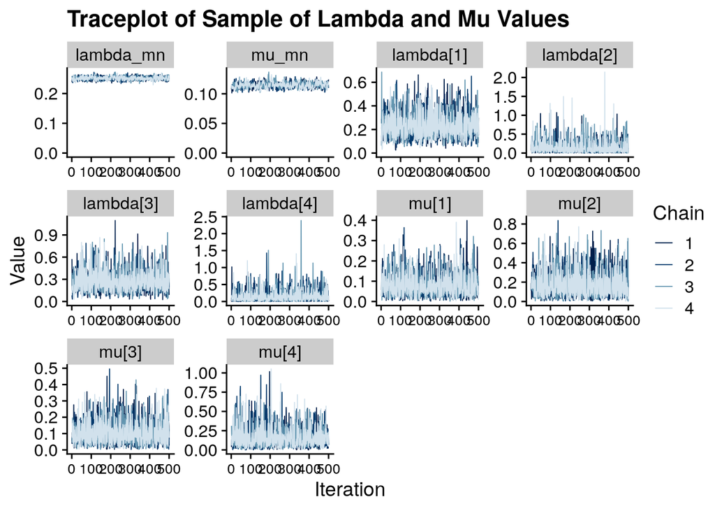

```r
parameter_subset <- c(
  "lambda_mn", "mu_mn",
  "lambda[1]", "lambda[2]", "lambda[3]", "lambda[4]",
  "mu[1]",     "mu[2]",     "mu[3]",     "mu[4]"
  )

pnbd_short_twohiermean_stanfit$draws(inc_warmup = FALSE) |>
  mcmc_trace(pars = parameter_subset) +
  expand_limits(y = 0) +
  labs(
    x = "Iteration",
    y = "Value",
    title = "Traceplot of Sample of Lambda and Mu Values"
    ) +
  theme(axis.text.x = element_text(size = 10))
```

We also check $N_{eff}$ as a quick diagnostic of the fit.

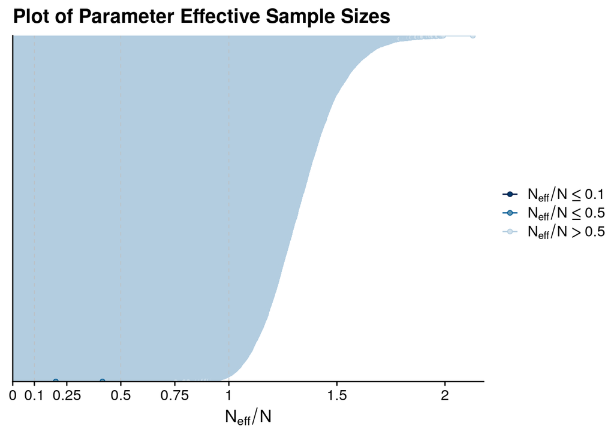

```r
pnbd_short_twohiermean_stanfit |>
  neff_ratio(pars = c("lambda_mn", "mu_mn", "lambda", "mu")) |>
  mcmc_neff() +
    ggtitle("Plot of Parameter Effective Sample Sizes")
```

Finally, we want to check out the energy diagnostic, which is often indicative of problems with the posterior mixing.

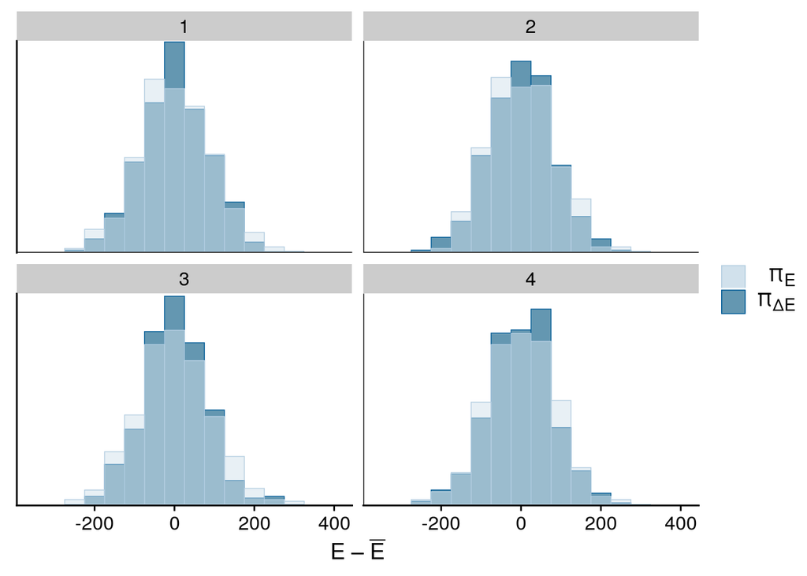

```r
pnbd_short_twohiermean_stanfit |>
  nuts_params() |>
  mcmc_nuts_energy(binwidth = 50)
```

## 1.3 Assess the Model

As we intend to run the same logic to assess each of our models, we have combined all this logic into a single function `run_model_assessment`, to run the simulations and combine the datasets.

```r
pnbd_stanfit <- pnbd_short_twohiermean_stanfit |>
  recover_types(customer_fit_stats_tbl)

pnbd_short_twohiermean_assess_data_lst <- run_model_assessment(
  model_stanfit    = pnbd_stanfit,
  insample_tbl     = customer_fit_subset_tbl,
  fit_label        = "pnbd_short_twohiermean",
  fit_end_dttm     = use_fit_end_date     |> as.POSIXct(),
  valid_start_dttm = use_valid_start_date |> as.POSIXct(),
  valid_end_dttm   = use_valid_end_date   |> as.POSIXct(),
  sim_seed         = 5210
  )

pnbd_short_twohiermean_assess_data_lst |> glimpse()
```

```
List of 5
 $ model_fit_index_filepath     : 'glue' chr "data/pnbd_short_twohiermean_assess_fit_index_tbl.rds"
 $ model_valid_index_filepath   : 'glue' chr "data/pnbd_short_twohiermean_assess_valid_index_tbl.rds"
 $ model_simstats_filepath      : 'glue' chr "data/pnbd_short_twohiermean_assess_model_simstats_tbl.rds"
 $ model_fit_simstats_filepath  : 'glue' chr "data/pnbd_short_twohiermean_assess_fit_simstats_tbl.rds"
 $ model_valid_simstats_filepath: 'glue' chr "data/pnbd_short_twohiermean_assess_valid_simstats_tbl.rds"
```

### 1.3.1 Check In-Sample Data Validation

We first check the model against the in-sample data.

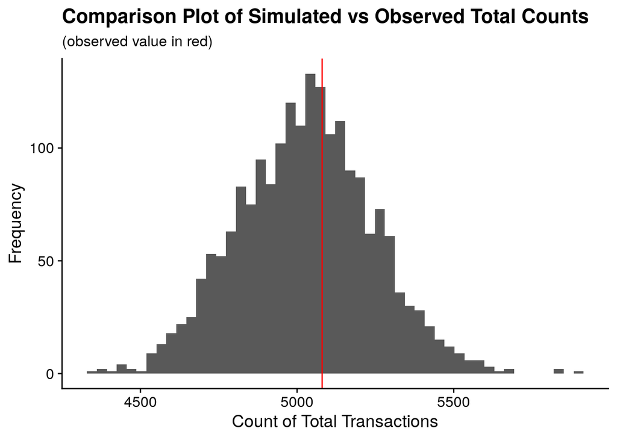

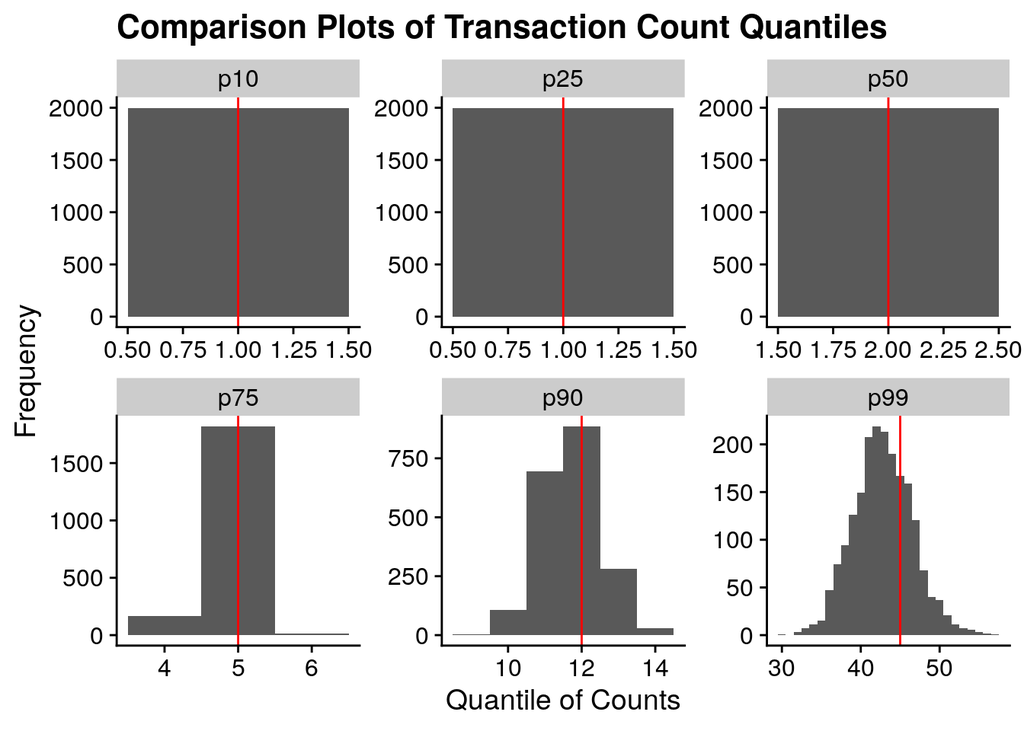

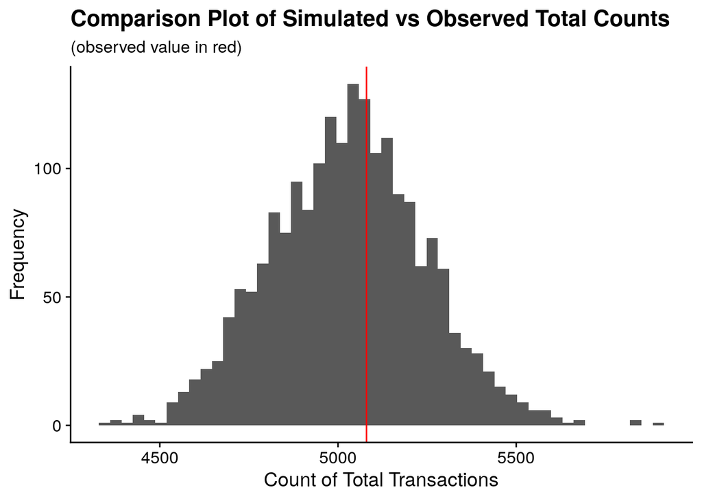

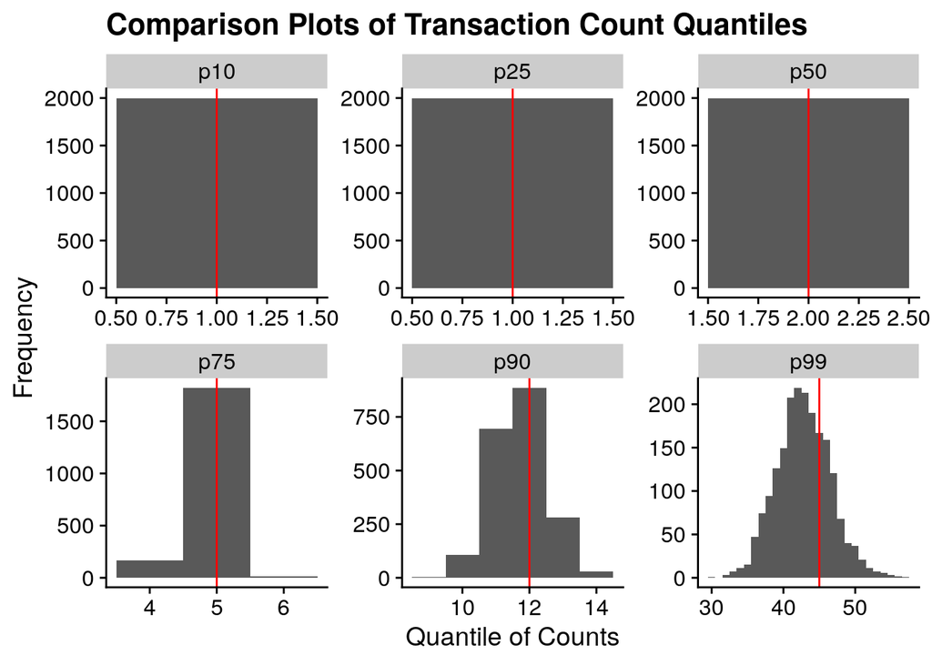

```r
simdata_tbl <- pnbd_short_twohiermean_assess_data_lst |>
  use_series(model_fit_index_filepath) |>
  read_rds() |>
  use_series(sim_file) |>
  map_dfr(read_rds) |>
  select(customer_id, draw_id, sim_data) |>
  unnest(sim_data) |>
  bind_rows(sim_init_tbl) |>
  arrange(customer_id, draw_id, tnx_timestamp)


assess_plots_lst <- create_model_assessment_plots(
  obsdata_tbl = customer_fit_transactions_tbl,
  simdata_tbl = simdata_tbl
  )

assess_plots_lst |> map(print)
```

This fit looks reasonable and appears to capture most of the aspects of the data used to fit it. Given that this is a synthetic dataset, this is not surprising, but at least we appreciate that our model is valid.

### 1.3.2 Check Out-of-Sample Data Validation

We now repeat for the out-of-sample data.

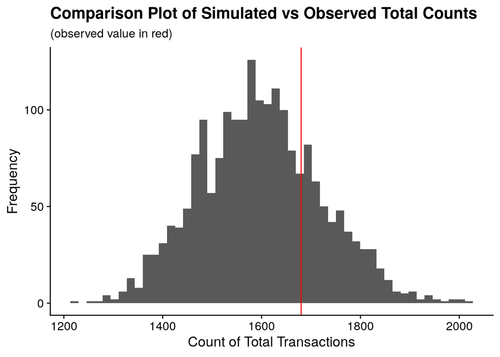

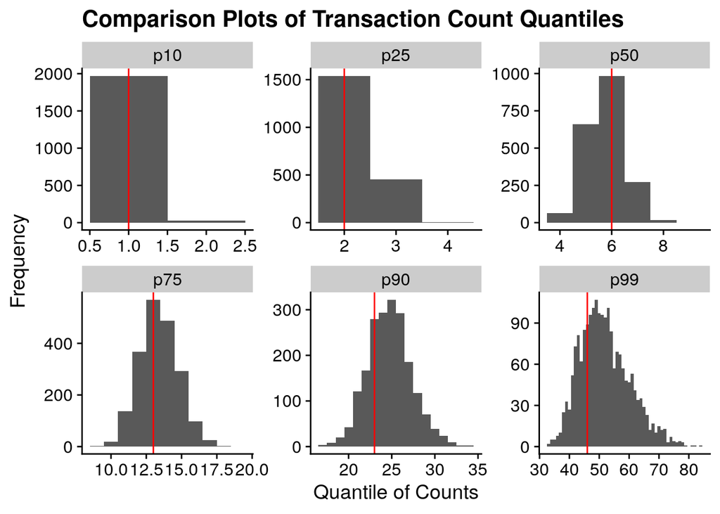

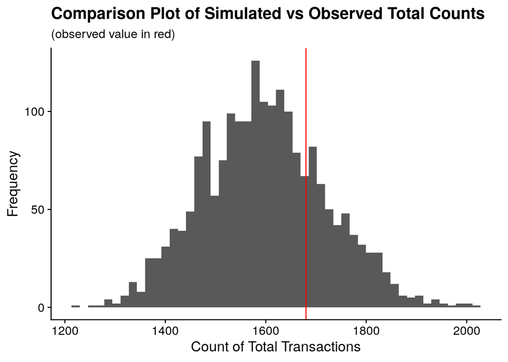

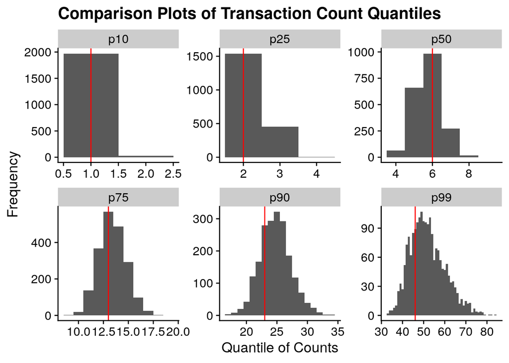

```r
simdata_tbl <- pnbd_short_twohiermean_assess_data_lst |>
  use_series(model_valid_index_filepath) |>
  read_rds() |>
  use_series(sim_file) |>
  map_dfr(read_rds) |>
  select(customer_id, draw_id, sim_data) |>
  unnest(sim_data) |>
  arrange(customer_id, draw_id, tnx_timestamp)


assess_plots_lst <- create_model_assessment_plots(
  obsdata_tbl = customer_valid_transactions_tbl,
  simdata_tbl = simdata_tbl
  )

assess_plots_lst |> map(print)
```

As for our short time frame data, overall our model is working well.

# 2 Fit Hierarchical Lambda Model

Our next model puts a hierarchical prior around both $\lambda$ parameters, `lambda_mn` and `lambda_cv`.

Once again we use a Gamma prior for both these parameters.

## 2.1 Compile and Fit Stan Model

We now compile this model using `CmdStanR`.

```r
pnbd_twohierlambda_stanmodel <- cmdstan_model(
  "stan_code/pnbd_twohier_lambda.stan",
  include_paths =   stan_codedir,
  pedantic      =           TRUE,
  dir           =  stan_modeldir
  )
```

We then use this compiled model with our data to produce a fit of the data.

```r
stan_modelname <- "pnbd_short_twohierlambda"
stanfit_prefix <- str_c("fit_", stan_modelname)
stanfit_seed   <- stanfit_seed + 1

stanfit_object_file <- glue("data/{stanfit_prefix}_stanfit.rds")


stan_data_lst <- customer_fit_stats_tbl |>
  select(customer_id, x, t_x, T_cal) |>
  compose_data(
    hier_lambda_mn_p1 = 0.25,
    hier_lambda_mn_p2 = 1.00,

    hier_lambda_cv_p1 = 1.00,
    hier_lambda_cv_p2 = 1.00,

    mu_mn             = 0.10,
    mu_cv             = 1.00
    )

if(!file_exists(stanfit_object_file)) {
  pnbd_short_twohierlambda_stanfit <- pnbd_twohierlambda_stanmodel$sample(
    data            =                stan_data_lst,
    chains          =                            4,
    iter_warmup     =                          500,
    iter_sampling   =                          500,
    seed            =                 stanfit_seed,
    save_warmup     =                         TRUE,
    output_dir      =                stan_modeldir,
    output_basename =               stanfit_prefix,
    )

  pnbd_short_twohierlambda_stanfit$save_object(stanfit_object_file, compress = "gzip")

} else {
  message(glue("Found file {stanfit_object_file}. Loading..."))

  pnbd_short_twohierlambda_stanfit <- read_rds(stanfit_object_file)
}

pnbd_short_twohierlambda_stanfit$print()
```

```
  variable      mean    median    sd   mad        q5       q95 rhat ess_bulk
 lp__      -46864.25 -46867.00 93.64 90.96 -47012.81 -46698.18 1.01      204
 lambda_mn      0.25      0.25  0.01  0.01      0.24      0.26 1.00     1375
 lambda_cv      1.06      1.06  0.03  0.02      1.02      1.10 1.01      223
 lambda[1]      0.23      0.21  0.11  0.11      0.08      0.44 1.00     2055
 lambda[2]      0.14      0.07  0.18  0.09      0.00      0.50 1.00     1843
 lambda[3]      0.27      0.24  0.15  0.13      0.08      0.56 1.00     2370
 lambda[4]      0.13      0.07  0.17  0.08      0.00      0.45 1.00     1619
 lambda[5]      0.13      0.07  0.16  0.09      0.00      0.46 1.01     2266
 lambda[6]      0.30      0.28  0.13  0.11      0.12      0.53 1.00     2943
 lambda[7]      0.14      0.11  0.11  0.09      0.02      0.36 1.00     2281
 ess_tail
      192
     1525
      233
      996
     1082
     1182
      942
      969
     1368
     1247

 # showing 10 of 9965 rows (change via 'max_rows' argument or 'cmdstanr_max_rows' option)
```

We have some basic HMC-based validity statistics we can check.

```r
pnbd_short_twohierlambda_stanfit$cmdstan_diagnose()
```

```
Processing csv files: /home/rstudio/btydwork/stan_models/fit_pnbd_short_twohierlambda-1.csvWarning: non-fatal error reading adaptation data
, /home/rstudio/btydwork/stan_models/fit_pnbd_short_twohierlambda-2.csvWarning: non-fatal error reading adaptation data
, /home/rstudio/btydwork/stan_models/fit_pnbd_short_twohierlambda-3.csvWarning: non-fatal error reading adaptation data
, /home/rstudio/btydwork/stan_models/fit_pnbd_short_twohierlambda-4.csvWarning: non-fatal error reading adaptation data


Checking sampler transitions treedepth.
Treedepth satisfactory for all transitions.

Checking sampler transitions for divergences.
No divergent transitions found.

Checking E-BFMI - sampler transitions HMC potential energy.
E-BFMI satisfactory.

Effective sample size satisfactory.

Split R-hat values satisfactory all parameters.

Processing complete, no problems detected.
```

## 2.2 Visual Diagnostics of the Sample Validity

Now that we have a sample from the posterior distribution we need to create a few different visualisations of the diagnostics.

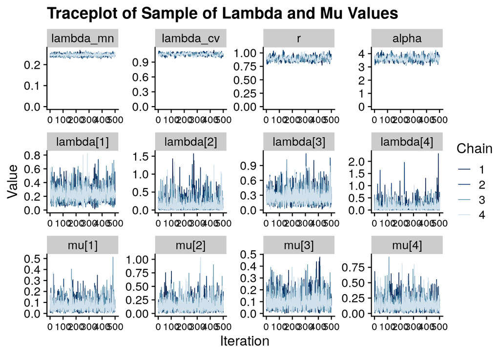

```r
parameter_subset <- c(
  "lambda_mn", "lambda_cv", "r", "alpha",
  "lambda[1]", "lambda[2]", "lambda[3]", "lambda[4]",
  "mu[1]",     "mu[2]",     "mu[3]",     "mu[4]"
  )

pnbd_short_twohierlambda_stanfit$draws(inc_warmup = FALSE) |>
  mcmc_trace(pars = parameter_subset) +
  expand_limits(y = 0) +
  labs(
    x = "Iteration",
    y = "Value",
    title = "Traceplot of Sample of Lambda and Mu Values"
    ) +
  theme(axis.text.x = element_text(size = 10))
```

We also check $N_{eff}$ as a quick diagnostic of the fit.

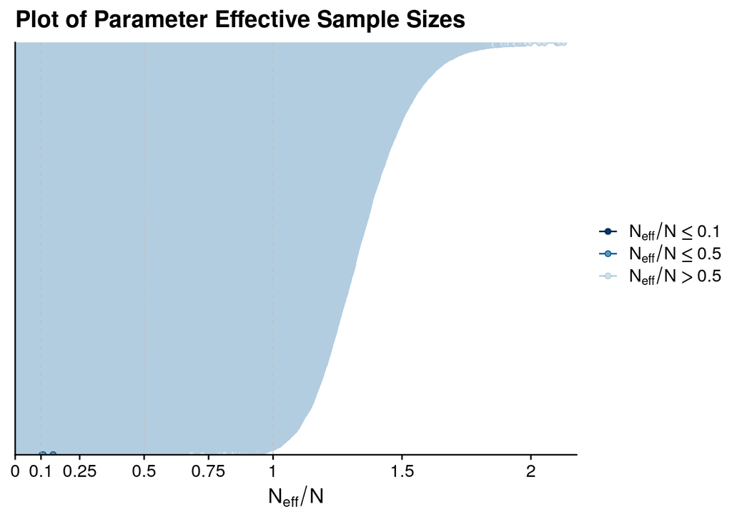

```r
pnbd_short_twohierlambda_stanfit |>
  neff_ratio(
    pars = c("lambda_mn", "lambda_cv", "r", "alpha", "lambda", "mu")
    ) |>
  mcmc_neff() +
    ggtitle("Plot of Parameter Effective Sample Sizes")
```

Finally, we want to check out the energy diagnostic, which is often indicative of problems with the posterior mixing.

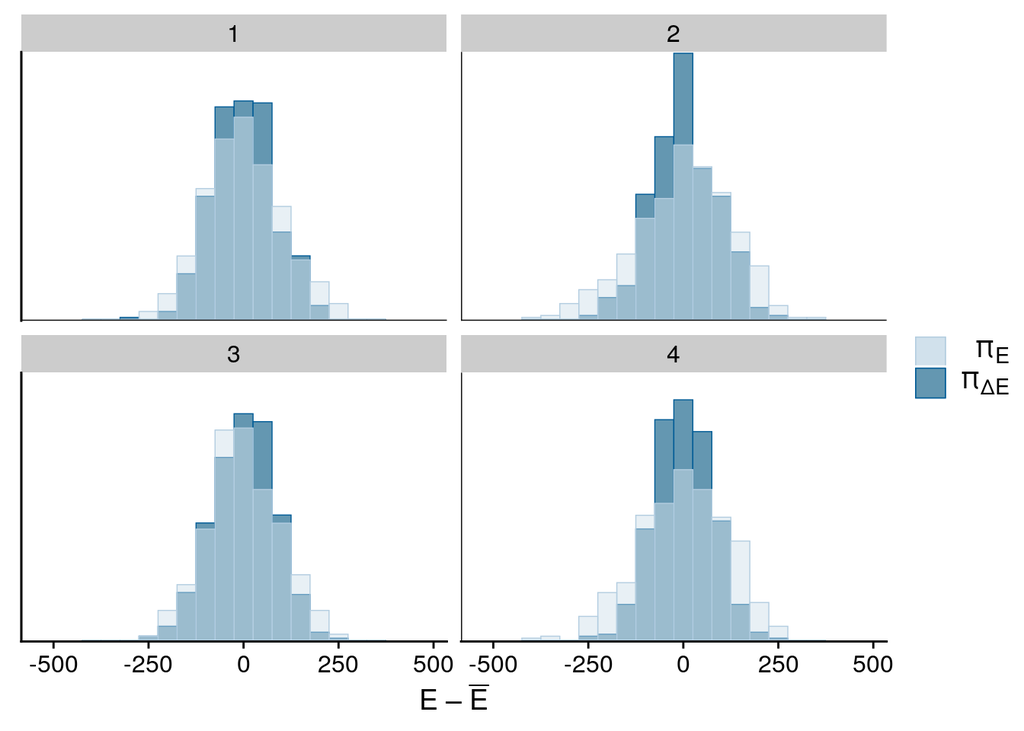

```r
pnbd_short_twohierlambda_stanfit |>
  nuts_params() |>
  mcmc_nuts_energy(binwidth = 50)
```

## 2.3 Assess the Model

As we intend to run the same logic to assess each of our models, we have combined all this logic into a single function `run_model_assessment`, to run the simulations and combine the datasets.

```r
pnbd_stanfit <- pnbd_short_twohierlambda_stanfit |>
  recover_types(customer_fit_stats_tbl)

pnbd_short_twohierlambda_assess_data_lst <- run_model_assessment(
  model_stanfit    = pnbd_stanfit,
  insample_tbl     = customer_fit_subset_tbl,
  fit_label        = "pnbd_short_twohierlambda",
  fit_end_dttm     = use_fit_end_date     |> as.POSIXct(),
  valid_start_dttm = use_valid_start_date |> as.POSIXct(),
  valid_end_dttm   = use_valid_end_date   |> as.POSIXct(),
  sim_seed         = 5220
  )

pnbd_short_twohierlambda_assess_data_lst |> glimpse()
```

```
List of 5
 $ model_fit_index_filepath     : 'glue' chr "data/pnbd_short_twohierlambda_assess_fit_index_tbl.rds"
 $ model_valid_index_filepath   : 'glue' chr "data/pnbd_short_twohierlambda_assess_valid_index_tbl.rds"
 $ model_simstats_filepath      : 'glue' chr "data/pnbd_short_twohierlambda_assess_model_simstats_tbl.rds"
 $ model_fit_simstats_filepath  : 'glue' chr "data/pnbd_short_twohierlambda_assess_fit_simstats_tbl.rds"
 $ model_valid_simstats_filepath: 'glue' chr "data/pnbd_short_twohierlambda_assess_valid_simstats_tbl.rds"
```

### 2.3.1 Check In-Sample Data Validation

We first check the model against the in-sample data.

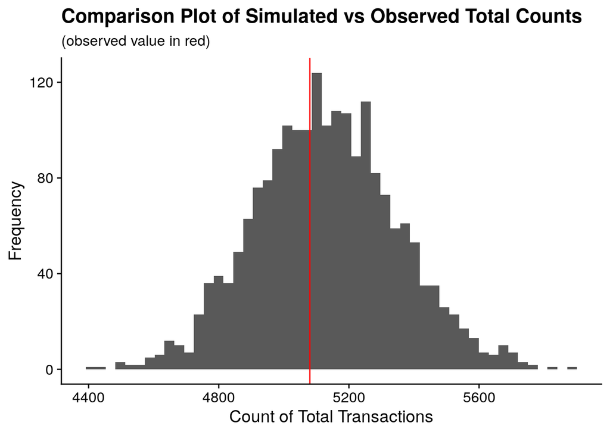

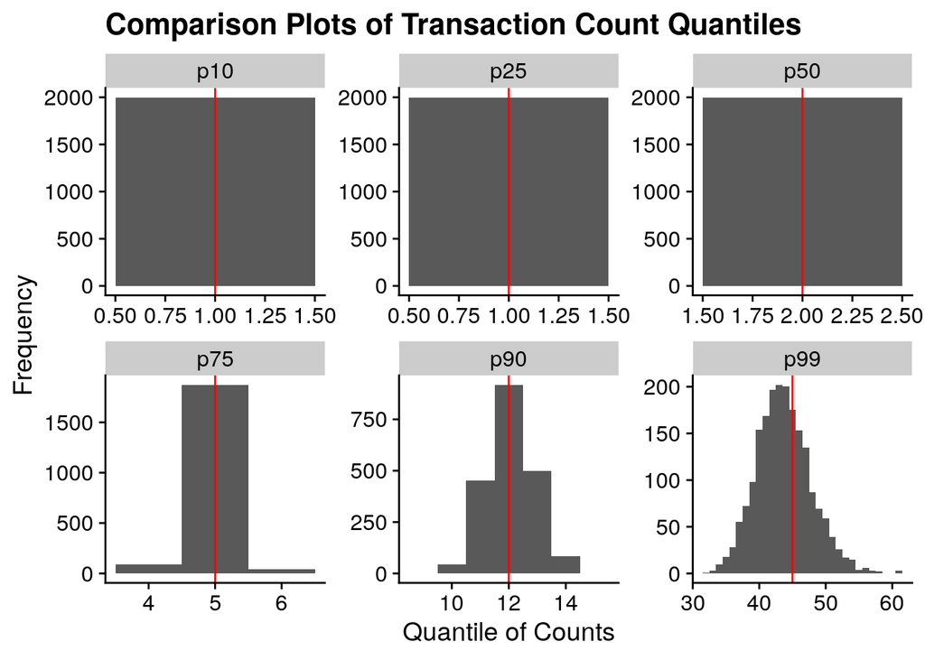

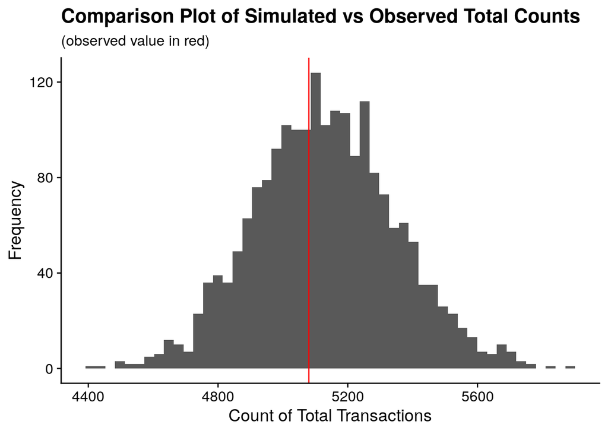

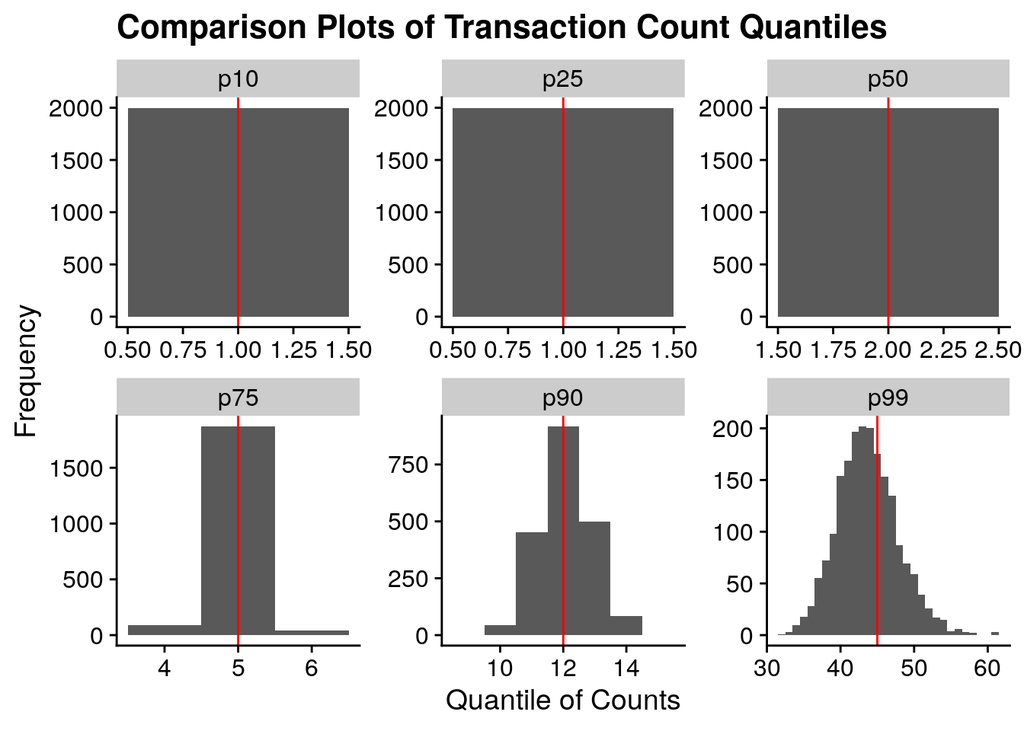

```r
simdata_tbl <- pnbd_short_twohierlambda_assess_data_lst |>
  use_series(model_fit_index_filepath) |>
  read_rds() |>
  use_series(sim_file) |>
  map_dfr(read_rds) |>
  select(customer_id, draw_id, sim_data) |>
  unnest(sim_data) |>
  bind_rows(sim_init_tbl) |>
  arrange(customer_id, draw_id, tnx_timestamp)


assess_plots_lst <- create_model_assessment_plots(
  obsdata_tbl = customer_fit_transactions_tbl,
  simdata_tbl = simdata_tbl
  )

assess_plots_lst |> map(print)
```

This fit looks reasonable and appears to capture most of the aspects of the data used to fit it. Given that this is a synthetic dataset, this is not surprising, but at least we appreciate that our model is valid.

### 2.3.2 Check Out-of-Sample Data Validation

We now repeat for the out-of-sample data.

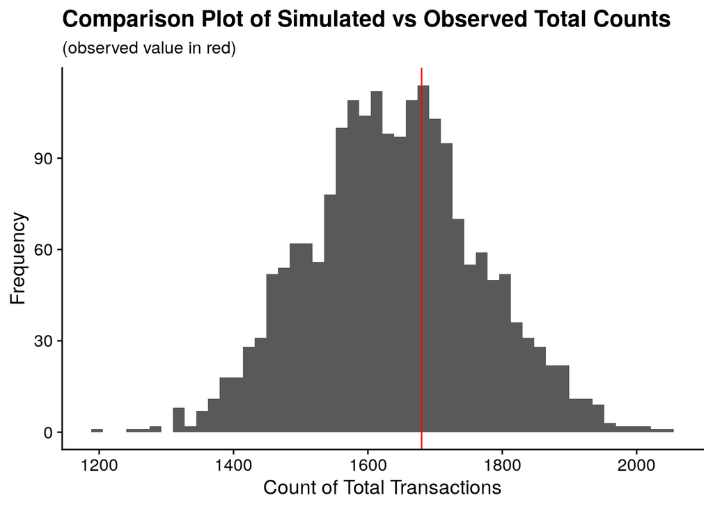

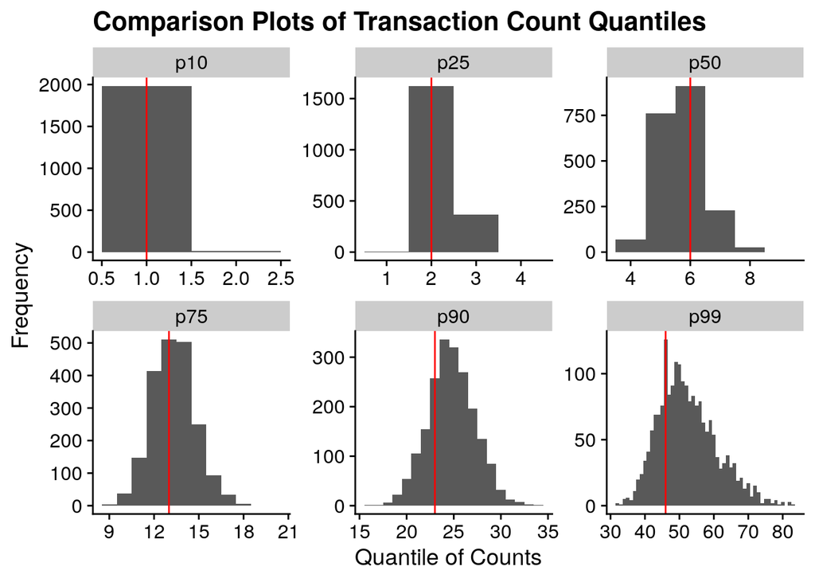

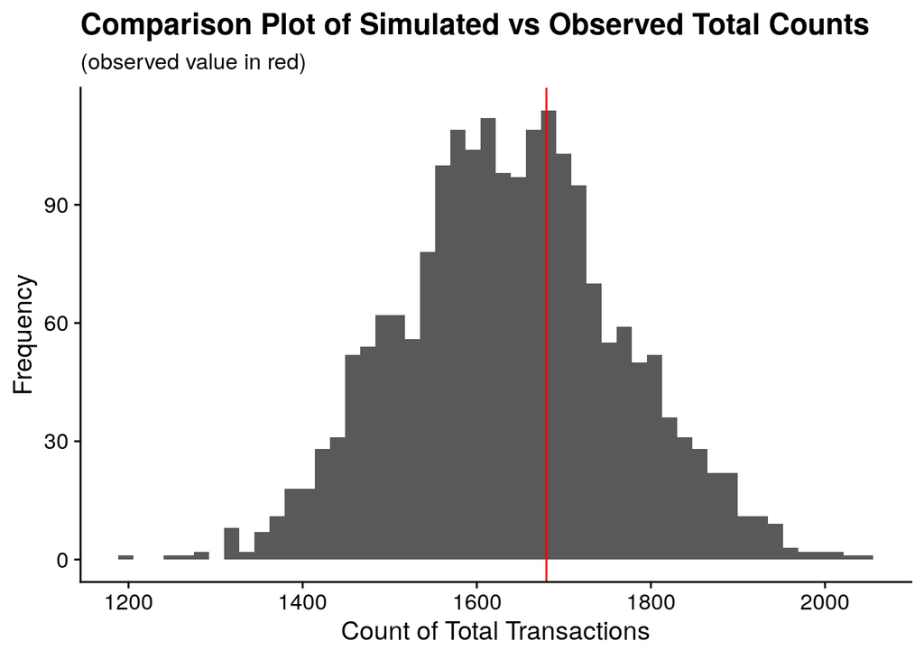

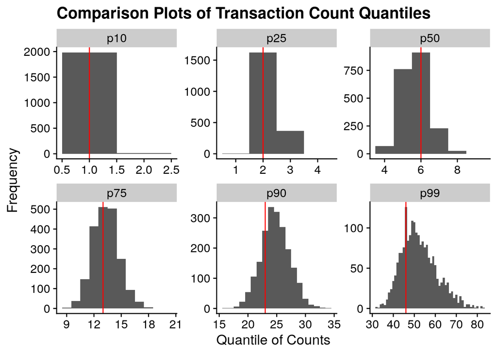

```r
simdata_tbl <- pnbd_short_twohierlambda_assess_data_lst |>
  use_series(model_valid_index_filepath) |>
  read_rds() |>
  use_series(sim_file) |>
  map_dfr(read_rds) |>
  select(customer_id, draw_id, sim_data) |>
  unnest(sim_data) |>
  arrange(customer_id, draw_id, tnx_timestamp)


assess_plots_lst <- create_model_assessment_plots(
  obsdata_tbl = customer_valid_transactions_tbl,
  simdata_tbl = simdata_tbl
  )

assess_plots_lst |> map(print)
```

As for our short time frame data, overall our model is working well.

# 3 Compare Model Outputs

We have looked at each of the models individually, but it is also worth looking at each of the models as a group.

We now want to combine both the `fit` and `valid` transaction sets to calculate the summary statistics for both.

```r
obs_summstats_tbl <- list(
    fit   = customer_fit_transactions_tbl,
    valid = customer_valid_transactions_tbl
    ) |>
  bind_rows(.id = "assess_type") |>
  group_by(assess_type) |>
  calculate_transaction_summary_statistics() |>
  pivot_longer(
    cols      = !assess_type,
    names_to  = "label",
    values_to = "obs_value"
    )

obs_summstats_tbl |> glimpse()
```

```
Rows: 16
Columns: 3
$ assess_type <chr> "fit", "fit", "fit", "fit", "fit", "fit", "fit", "fit", "v…
$ label       <chr> "p10", "p25", "p50", "p75", "p90", "p99", "total_count", "…
$ obs_value   <dbl> 1.000000, 1.000000, 2.000000, 5.000000, 12.000000, 45.0000…
```

```r
model_assess_transactions_tbl <- dir_ls("data", regexp = "pnbd_short_(fixed|one|two).*_assess_.*index") |>
  enframe(name = NULL, value = "file_path") |>
  mutate(
    model_label = str_replace(file_path, "data/pnbd_short_(.*?)_assess_.*", "\\1"),
    assess_type = if_else(str_detect(file_path, "_assess_fit_"), "fit", "valid"),

    assess_data = map(
      file_path, construct_model_assessment_data,

      .progress = "construct_assess_data"
      )
    ) |>
  select(model_label, assess_type, assess_data) |>
  unnest(assess_data)

model_assess_transactions_tbl |> glimpse()
```

```
Rows: 99,734,427
Columns: 6
$ model_label   <chr> "fixed1", "fixed1", "fixed1", "fixed1", "fixed1", "fixed…
$ assess_type   <chr> "fit", "fit", "fit", "fit", "fit", "fit", "fit", "fit", …
$ customer_id   <fct> SFC202001_0004, SFC202001_0004, SFC202001_0004, SFC20200…
$ draw_id       <int> 3, 3, 3, 3, 4, 4, 6, 6, 6, 6, 6, 6, 6, 8, 8, 9, 9, 9, 10…
$ tnx_timestamp <dttm> 2020-01-02 21:24:06, 2020-01-10 06:43:55, 2020-01-15 18…
$ tnx_amount    <dbl> 4.41, 186.28, 40.43, 133.27, 52.23, 11.18, 219.15, 252.7…
```

We now want to calculate the transaction statistics on this full dataset, for each separate draw.

```r
model_assess_tbl <- model_assess_transactions_tbl |>
  group_by(model_label, assess_type, draw_id) |>
  calculate_transaction_summary_statistics()

model_assess_tbl |> glimpse()
```

```
Rows: 40,000
Columns: 11
$ model_label <chr> "fixed1", "fixed1", "fixed1", "fixed1", "fixed1", "fixed1"…
$ assess_type <chr> "fit", "fit", "fit", "fit", "fit", "fit", "fit", "fit", "f…
$ draw_id     <int> 1, 2, 3, 4, 5, 6, 7, 8, 9, 10, 11, 12, 13, 14, 15, 16, 17,…
$ p10         <dbl> 1, 1, 1, 1, 1, 1, 1, 1, 1, 1, 1, 1, 1, 1, 1, 1, 1, 1, 1, 1…
$ p25         <dbl> 1, 1, 1, 1, 1, 1, 1, 1, 1, 2, 1, 1, 1, 1, 1, 1, 2, 1, 1, 1…
$ p50         <dbl> 3.0, 3.0, 3.0, 3.0, 3.0, 3.0, 3.0, 3.0, 3.0, 3.0, 3.0, 3.0…
$ p75         <dbl> 7, 7, 9, 7, 8, 7, 7, 9, 7, 8, 7, 8, 8, 8, 8, 8, 7, 7, 8, 7…
$ p90         <dbl> 14.0, 17.2, 18.3, 18.0, 20.0, 16.1, 16.3, 21.0, 16.0, 17.0…
$ p99         <dbl> 55.52, 51.06, 53.39, 44.60, 50.18, 45.42, 44.86, 49.25, 45…
$ total_count <int> 3945, 4161, 4391, 4047, 4377, 3860, 3975, 4391, 4135, 4186…
$ mean_count  <dbl> 6.477833, 6.946578, 7.467687, 6.623568, 7.319398, 6.655172…
```

We now combine all this data to create a number of different comparison plots for the various summary statistics.

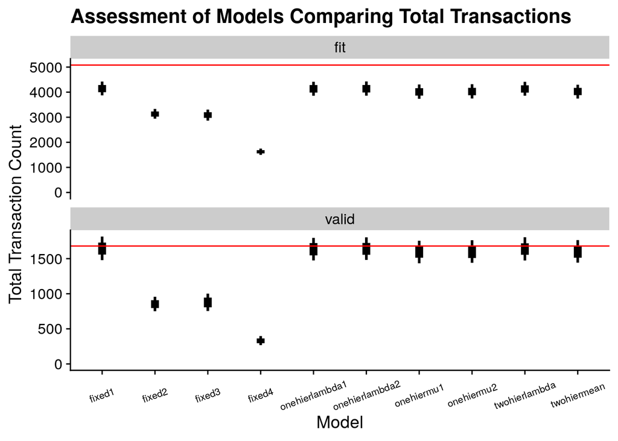

```r
#! echo: TRUE

create_multiple_model_assessment_plot(
  obs_summstats_tbl, model_assess_tbl,
  "total_count", "Total Transactions"
  )
```

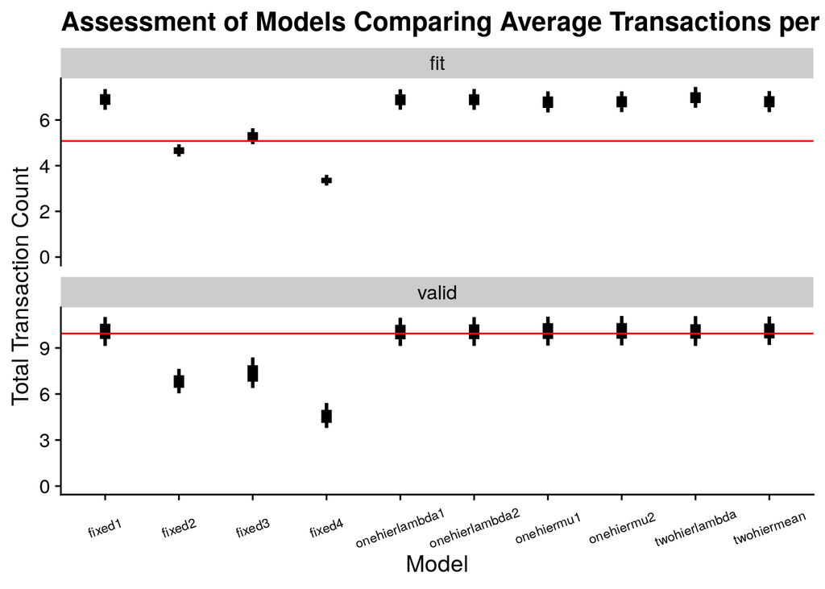

```r
create_multiple_model_assessment_plot(
  obs_summstats_tbl, model_assess_tbl,
  "mean_count", "Average Transactions per Customer"
  )
```

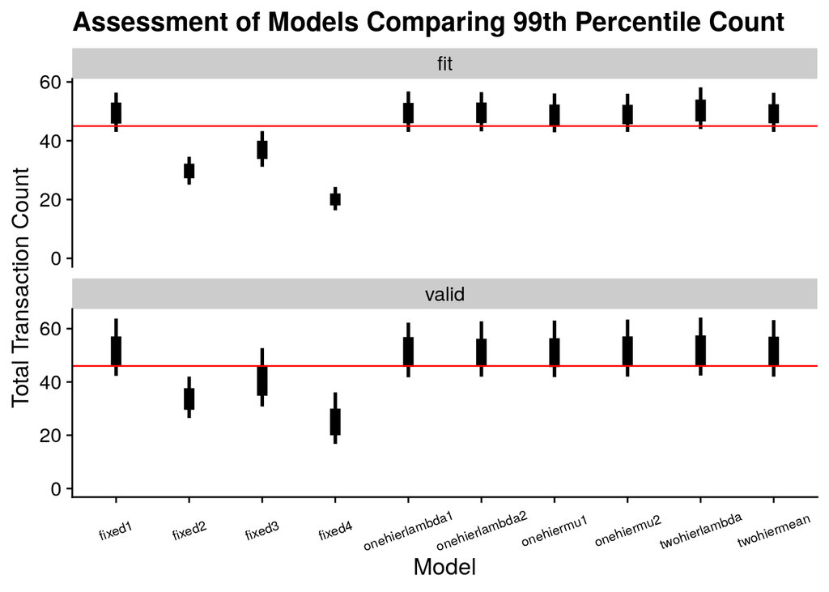

```r
create_multiple_model_assessment_plot(
  obs_summstats_tbl, model_assess_tbl,
  "p99", "99th Percentile Count"
  )
```

## 3.1 Write Assessment Data to Disk

We now want to save the assessment data to disk.

```r
model_assess_tbl |> write_rds("data/assess_data_pnbd_short_twohier_tbl.rds")
```

# R Environment

```r
options(width = 120L)
```

```r
options(width = 80L)
```